# Lending Club Data Analysis

## 1. Introduction

For this project, we wish to present and explore the data provided by Lending Club.

**Lending Club** is a peer-to-peer online lending platform. It is the world’s largest marketplace for personal loans that matches borrowers who are seeking a loan with investors looking to lend money and make a return. Each **borrower** fills out a comprehensive application, providing their past financial history, the reason for the loan, and more. Lending Club evaluates each borrower’s credit score using past historical data (and their own data science process!) and assigns an interest rate to the borrower.

The loan is then listed on the Lending Club marketplace.

[figure not shown]

```python
from IPython.display import Image
Image(filename = "LC1.jpg", width=900, height=900)
```

**Investors** are primarily interested in receiving a return on their investments. Approved loans are listed on the Lending Club website, where qualified investors can browse recently approved loans, the borrower’s credit score, the purpose for the loan, and other information from the application.

Once an investor decides to fund a loan, the borrower then makes monthly payments back to Lending Club. Lending Club redistributes these payments to the investors. This means that investors don’t have to wait until the full amount is paid off to start to see money back. If a loan is fully paid off on time, the investors make a return which corresponds to the interest rate the borrower had to pay in addition to the requested amount. Many loans aren’t completely paid off on time, however, and some borrowers **default** on the loan.

### How does an online credit marketplace work?

Lending Club uses technology to operate a credit marketplace at a lower cost than traditional bank loan programs, passing the savings on to borrowers in the form of lower rates and to investors in the form of solid returns. Borrowers who used a personal loan via Lending Club to consolidate debt or pay off high interest credit cards report in a survey that the interest rate on their loan was an average of 24% lower than they were paying on their outstanding debt or credit cards.

By providing borrowers with better rates, and investors with attractive, risk-adjusted returns, Lending Club has earned among the highest satisfaction ratings in the financial services industry.

[figure not shown]

```python
from IPython.display import Image
Image(filename = "LC2.png", width=1000, height=500)
```

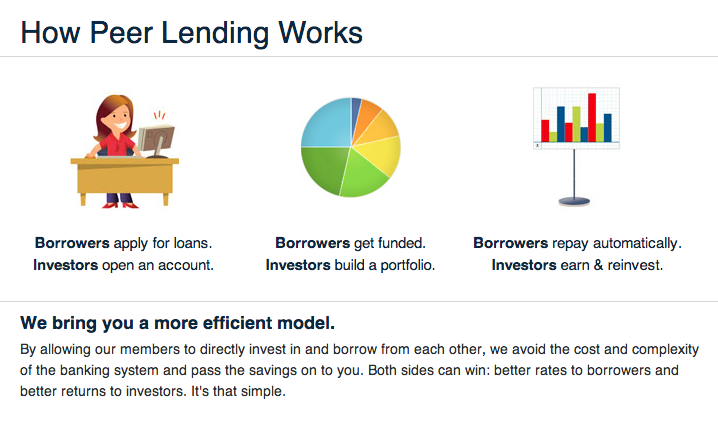

```python
from IPython.display import Image
Image(filename = "LC3.png", width=800, height=800)
```

## 2. Exploring the dataset!

### Data

https://www.lendingclub.com/info/download-data.action

```python
import pandas as pd
import numpy as np

import matplotlib.pyplot as plt
import seaborn as sns
sns.set(style="white", color_codes=True)
%matplotlib inline
```

```python
df = pd.read_csv('project/loan.csv')
df.head()
```

|  | id | member_id | loan_amnt | funded_amnt | funded_amnt_inv | term | int_rate | installment | grade | sub_grade | ... | total_bal_il | il_util | open_rv_12m | open_rv_24m | max_bal_bc | all_util | total_rev_hi_lim | inq_fi | total_cu_tl | inq_last_12m |
| --- | --- | --- | --- | --- | --- | --- | --- | --- | --- | --- | --- | --- | --- | --- | --- | --- | --- | --- | --- | --- | --- |
| 0 | 1077501 | 1296599 | 5000.0 | 5000.0 | 4975.0 | 36 months | 10.65 | 162.87 | B | B2 | ... | NaN | NaN | NaN | NaN | NaN | NaN | NaN | NaN | NaN | NaN |
| 1 | 1077430 | 1314167 | 2500.0 | 2500.0 | 2500.0 | 60 months | 15.27 | 59.83 | C | C4 | ... | NaN | NaN | NaN | NaN | NaN | NaN | NaN | NaN | NaN | NaN |
| 2 | 1077175 | 1313524 | 2400.0 | 2400.0 | 2400.0 | 36 months | 15.96 | 84.33 | C | C5 | ... | NaN | NaN | NaN | NaN | NaN | NaN | NaN | NaN | NaN | NaN |
| 3 | 1076863 | 1277178 | 10000.0 | 10000.0 | 10000.0 | 36 months | 13.49 | 339.31 | C | C1 | ... | NaN | NaN | NaN | NaN | NaN | NaN | NaN | NaN | NaN | NaN |
| 4 | 1075358 | 1311748 | 3000.0 | 3000.0 | 3000.0 | 60 months | 12.69 | 67.79 | B | B5 | ... | NaN | NaN | NaN | NaN | NaN | NaN | NaN | NaN | NaN | NaN |

5 rows × 74 columns

```python
df.info()
```

```
<class 'pandas.core.frame.DataFrame'>
RangeIndex: 887379 entries, 0 to 887378
Data columns (total 74 columns):
id                             887379 non-null int64
member_id                      887379 non-null int64
loan_amnt                      887379 non-null float64
funded_amnt                    887379 non-null float64
funded_amnt_inv                887379 non-null float64
term                           887379 non-null object
int_rate                       887379 non-null float64
installment                    887379 non-null float64
grade                          887379 non-null object
sub_grade                      887379 non-null object
emp_title                      835922 non-null object
emp_length                     887379 non-null object
home_ownership                 887379 non-null object
annual_inc                     887375 non-null float64
verification_status            887379 non-null object
issue_d                        887379 non-null object
loan_status                    887379 non-null object
pymnt_plan                     887379 non-null object
url                            887379 non-null object
desc                           126029 non-null object
purpose                        887379 non-null object
title                          887228 non-null object
zip_code                       887379 non-null object
addr_state                     887379 non-null object
dti                            887379 non-null float64
delinq_2yrs                    887350 non-null float64
earliest_cr_line               887350 non-null object
inq_last_6mths                 887350 non-null float64
mths_since_last_delinq         433067 non-null float64
mths_since_last_record         137053 non-null float64
open_acc                       887350 non-null float64
pub_rec                        887350 non-null float64
revol_bal                      887379 non-null float64
revol_util                     886877 non-null float64
total_acc                      887350 non-null float64
initial_list_status            887379 non-null object
out_prncp                      887379 non-null float64
```

[output cut: 24 more lines]

```
open_il_12m                    21372 non-null float64
open_il_24m                    21372 non-null float64
mths_since_rcnt_il             20810 non-null float64
total_bal_il                   21372 non-null float64
il_util                        18617 non-null float64
open_rv_12m                    21372 non-null float64
open_rv_24m                    21372 non-null float64
max_bal_bc                     21372 non-null float64
all_util                       21372 non-null float64
total_rev_hi_lim               817103 non-null float64
inq_fi                         21372 non-null float64
total_cu_tl                    21372 non-null float64
inq_last_12m                   21372 non-null float64
dtypes: float64(49), int64(2), object(23)
memory usage: 501.0+ MB
```

```python
df.shape
```

```
(887379, 74)
```

### Product Information

#### Loan Amount

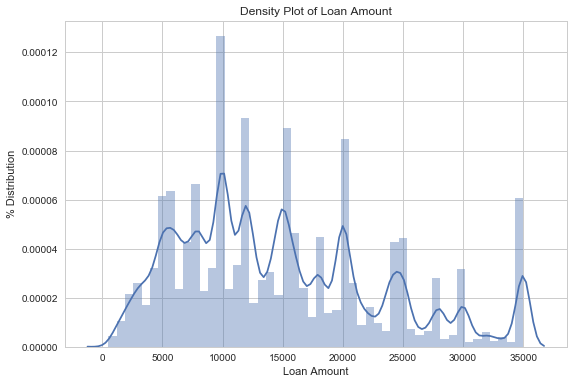

```python
plt.rcParams['figure.figsize'] = (9,6)
sns.set_style("whitegrid")
ax=sns.distplot(df.loan_amnt)
ax.set(xlabel='Loan Amount',
       ylabel='% Distribution',title='Density Plot of Loan Amount')
plt.legend()
```

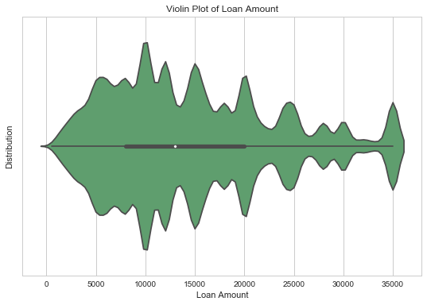

```python
ax = sns.violinplot(df.loan_amnt,color="g");
ax.set(xlabel='Loan Amount',
       ylabel='Distribution',title='Violin Plot of Loan Amount')

plt.legend();
```

```python
df['loan_amnt'].describe()
```

```
count    887379.000000
mean      14755.264605
std        8435.455601
min         500.000000
25%        8000.000000
50%       13000.000000
75%       20000.000000
max       35000.000000
Name: loan_amnt, dtype: float64
```

#### Loan Status

```python
loan_status_distribution=pd.DataFrame(df['loan_status'].value_counts())
loan_status_distribution.reset_index(inplace=True)
loan_status_distribution.columns=['Loan_Status_Category','Number of applicants']
loan_status_distribution
```

|  | Loan_Status_Category | Number of applicants |
| --- | --- | --- |
| 0 | Current | 601779 |
| 1 | Fully Paid | 207723 |
| 2 | Charged Off | 45248 |
| 3 | Late (31-120 days) | 11591 |
| 4 | Issued | 8460 |
| 5 | In Grace Period | 6253 |
| 6 | Late (16-30 days) | 2357 |
| 7 | Does not meet the credit policy. Status:Fully ... | 1988 |
| 8 | Default | 1219 |
| 9 | Does not meet the credit policy. Status:Charge... | 761 |

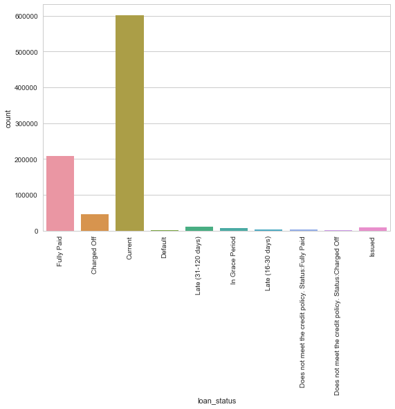

```python
sns.countplot(df['loan_status'])
plt.xticks(rotation=90)
plt.show()
```

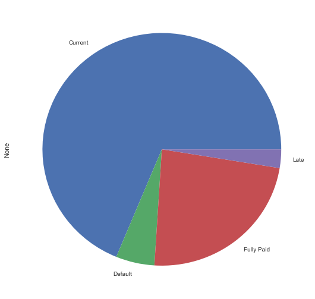

```python
plt.rcParams['figure.figsize'] = (9,9)
def status_class(text):
    if text=='Fully Paid':
        return 'Fully Paid'
    elif text=='Charged Off' or text=='Default':
        return 'Default'
    elif text=='Current' or text=='Issued':
        return 'Current'
    else:
        return 'Late'

df['status_class']=df['loan_status'].apply(status_class)
df.groupby('status_class').size().plot(kind='pie')
```

#### Purpose

```python
df["purpose"].unique()
```

```
array(['credit_card', 'car', 'small_business', 'other', 'wedding',
       'debt_consolidation', 'home_improvement', 'major_purchase',
       'medical', 'moving', 'vacation', 'house', 'renewable_energy',
       'educational'], dtype=object)
```

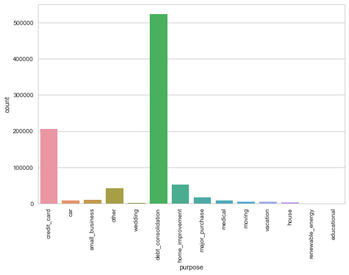

```python
plt.rcParams['figure.figsize'] = (9,6)
sns.countplot(df['purpose'])
plt.xticks(rotation=90)
plt.show()
```

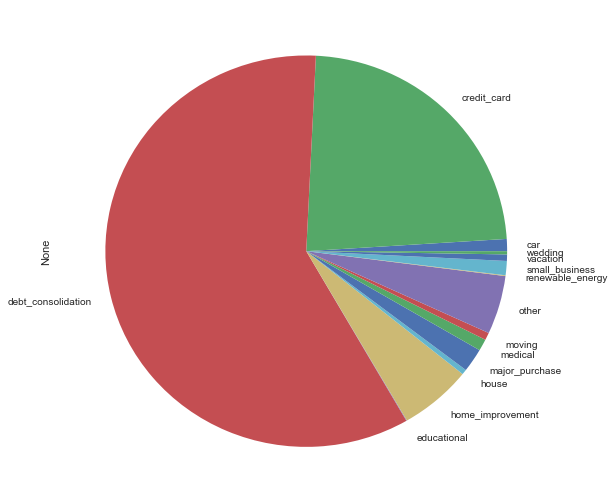

```python
plt.rcParams['figure.figsize'] = (9,9)
df.groupby('purpose').size().plot(kind='pie')
```

#### Term

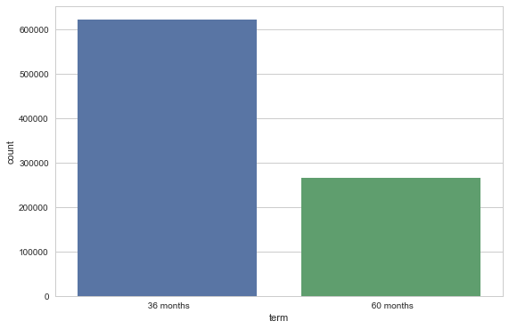

```python
plt.rcParams['figure.figsize'] = (9,6)
sns.countplot(df['term'])
```

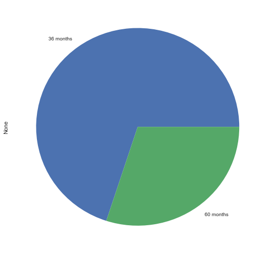

```python
plt.rcParams['figure.figsize'] = (9,9)
df.groupby('term').size().plot(kind='pie')
```

#### Application Type

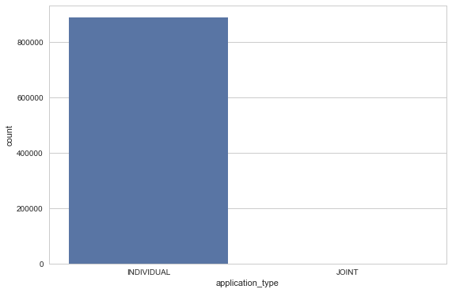

```python
plt.rcParams['figure.figsize'] = (9,6)
sns.countplot(df['application_type'])
```

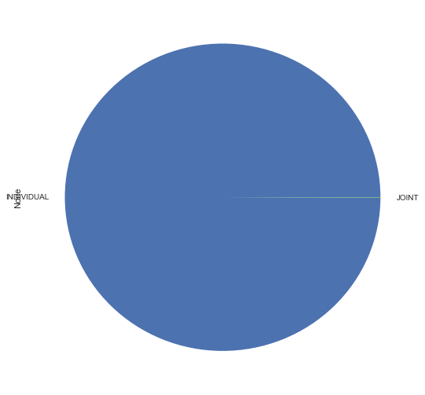

```python
plt.rcParams['figure.figsize'] = (9,9)
df.groupby('application_type').size().plot(kind='pie')
```

### Client Information

#### Employment Length

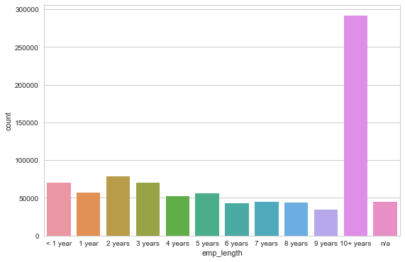

```python
plt.rcParams['figure.figsize'] = (9,6)
sns.countplot(df['emp_length'], order = ('< 1 year', '1 year', '2 years', '3 years', '4 years', '5 years', '6 years',
                                         '7 years', '8 years', '9 years', '10+ years', 'n/a'))
```

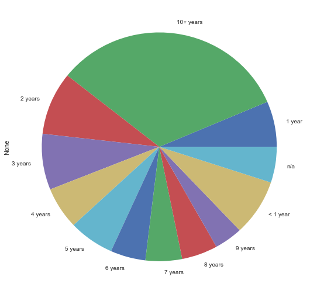

```python
plt.rcParams['figure.figsize'] = (9,9)
df.groupby('emp_length').size().plot(kind='pie')
```

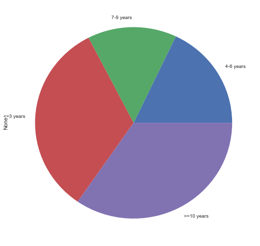

```python
def emp_length_class(text):
    if text=='< 1 year' or text=='1 year' or text=='2 years' or text=='3 years':
        return '<=3 years'
    elif text=='4 years' or text=='5 years' or text=='6 years':
        return '4-6 years'
    elif text=='7 years' or text=='8 years' or text=='9 years':
        return '7-9 years'
    elif text=='10+ years':
        return '>=10 years'
    else:
        return None

df['emp_length_class']=df['emp_length'].apply(emp_length_class)
df.groupby('emp_length_class').size().plot(kind='pie')
```

#### Annual Income

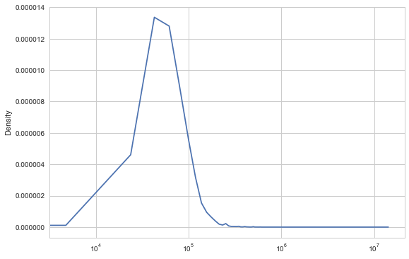

```python
plt.rcParams['figure.figsize'] = (9,6)
df["annual_inc"].plot.density(logx = True)
```

```python
df["annual_inc"].describe()
```

```
count    8.873750e+05
mean     7.502759e+04
std      6.469830e+04
min      0.000000e+00
25%      4.500000e+04
50%      6.500000e+04
75%      9.000000e+04
max      9.500000e+06
Name: annual_inc, dtype: float64
```

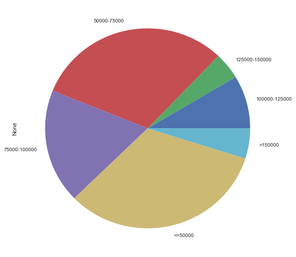

```python
plt.rcParams['figure.figsize'] = (9,9)
def inc_class(num):
    if num <= 50000:
        return '<=50000'
    elif num <= 75000:
        return '50000-75000'
    elif num <= 100000:
        return '75000-100000'
    elif num <= 125000:
        return '100000-125000'
    elif num <= 150000:
        return '125000-150000'
    else:
        return '>150000'

df['inc_class']=df['annual_inc'].apply(inc_class)
df.groupby('inc_class').size().plot(kind='pie')
```

### Interest Rate

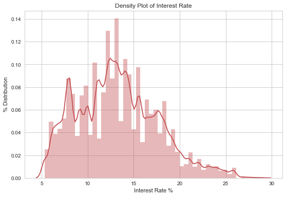

```python
plt.rcParams['figure.figsize'] = (9,6)
ax=sns.distplot(df.int_rate, color="r")
ax.set(xlabel='Interest Rate %',
       ylabel='% Distribution',title='Density Plot of Interest Rate')

plt.legend();
```

#### Interest Rate by Term

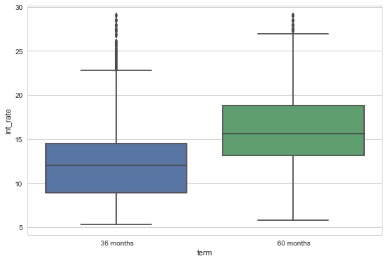

```python
sns.boxplot(x='term', y='int_rate', data=df)
```

#### Interest Rate by Employment Length

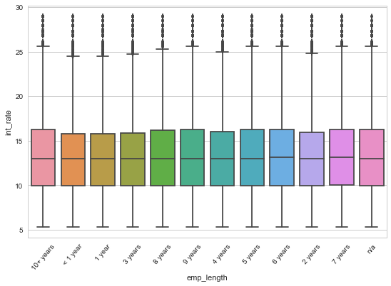

```python
sns.boxplot(x='emp_length', y='int_rate', data=df)
plt.xticks(rotation=50)
plt.show()
```

#### Interest Rate by Purpose

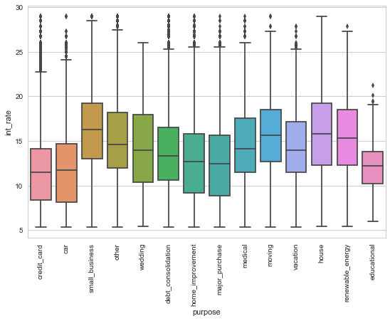

```python
sns.boxplot(x='purpose', y='int_rate', data=df)
plt.xticks(rotation=90)
plt.show()
```

#### Interest Rate by Application Type

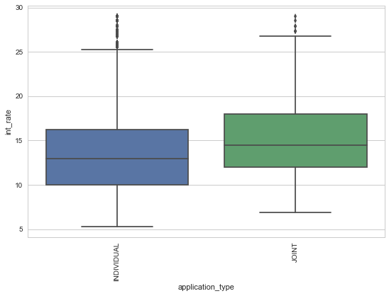

```python
sns.boxplot(x='application_type', y='int_rate', data=df)
plt.xticks(rotation=90)
plt.show()
```

### Credit Grade

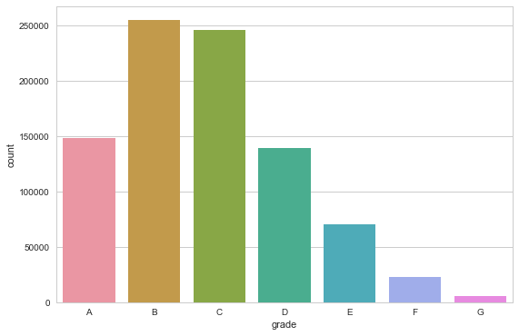

```python
plt.rcParams['figure.figsize'] = (9,6)
sns.countplot(df['grade'], order = ('A','B','C','D','E','F','G'))
```

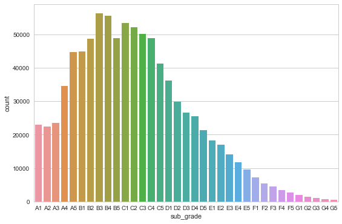

```python
l = []
for i in ['A', 'B', 'C', 'D', 'E', 'F', 'G']:
    for j in ['1', '2', '3', '4', '5']:
        l.append(i+j)

sns.countplot(df['sub_grade'], order = l)
```

#### Interest Rate by Grade

```python
df.groupby("grade")["int_rate"].mean()
```

```
grade
A     7.243312
B    10.829618
C    13.980098
D    17.175814
E    19.897322
F    23.582787
G    25.626706
Name: int_rate, dtype: float64
```

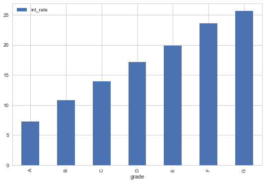

```python
df[['grade','int_rate']].groupby('grade').mean().plot(kind='bar')
```

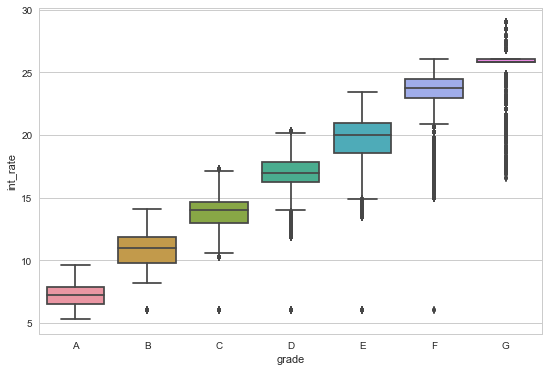

```python
sns.boxplot(x='grade', y='int_rate', data=df, order = 'ABCDEFG')
```

#### Loan Amount by Grade

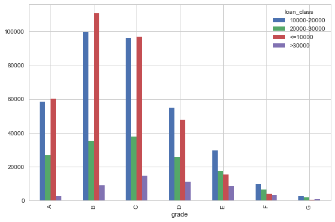

```python
def loan_class(num):
    if num <= 10000:
        return '<=10000'
    elif num <= 20000:
        return '10000-20000'
    elif num <= 30000:
        return '20000-30000'
    else:
        return '>30000'

df['loan_class']=df['loan_amnt'].apply(loan_class)
df.groupby(['grade','loan_class']).size().unstack().plot(kind='bar')
```

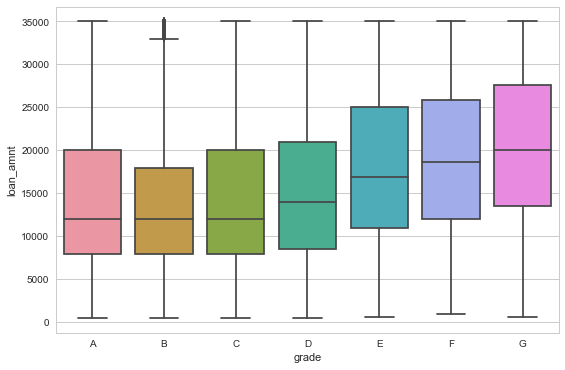

```python
sns.boxplot(x='grade', y='loan_amnt', data=df, order = 'ABCDEFG')
```

#### Term by Grade

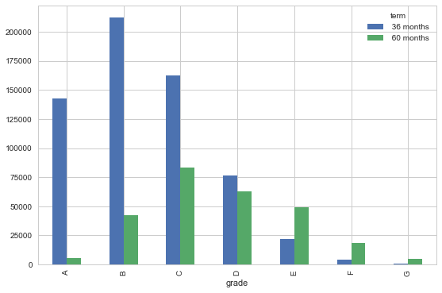

```python
df.groupby(['grade','term']).size().unstack().plot(kind='bar')
```

#### Loan Status by Grade

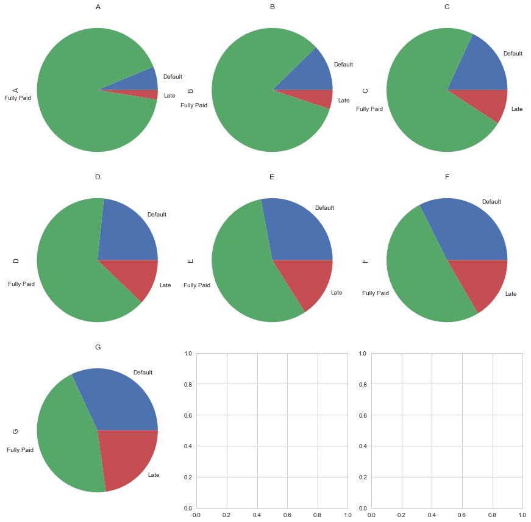

```python
grade_status = df[df['status_class']!='Current'].groupby(['status_class','grade']).size().unstack()
COL_NUM = 3
ROW_NUM = 3
fig, axes = plt.subplots(ROW_NUM, COL_NUM, figsize=(12,12))

for i, (grade, status_count) in enumerate(grade_status.items()):
    ax = axes[int(i/COL_NUM), i%COL_NUM]
    status_count.plot(kind='pie', ax=ax)
    ax.set_title(grade)

plt.tight_layout()
```